# Manipulación y agrupación de datos

Teresa Ortiz, Amaury Gutiérrez

Febrero 2015

En estas notas continuamos con la introducción a R para análisis de datos, en particular mostraremos herramientas de manipulación de datos. Trataremos los siguientes puntos:

- Reestructura de datos y el principio de los datos limpios.
- Estrategia divide-aplica-combina.

### Análisis de datos

En el análisis de datos nos interesan técnicas cuantitativas: cómo recolectar, organizar, entender, interpretar y extraer información de colecciones de datos predominantemente numéricos. Todas estas tareas son parte de un proceso que podría resumirse con el siguiente diagrama (Hadley Wickham):

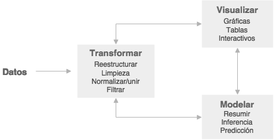

Para poder recorrer el diagrama suavemente es útil conocer las herramientas adecuadas de manipulación de datos, es sorprendente lo que unas cuantas funciones pueden ayudar. Comenzaremos con las herramientas de limpieza de datos pues este debe ser el primer paso de cualquier análisis.

### Datos limpios

Los **datos limpios** son datos que facilitan las tareas del análisis de datos:

- **Manipulación**: Manipulación de variables como agregar, filtrar, reordenar, transformar.
- **Visualización**: Resúmenes de datos usando gráficas, análisis exploratorio, o presentación de resultados.
- **Modelación**: Ajustar modelos es sencillo si los datos están en la forma correcta.

Los principios de **datos limpios** ([Tidy Data de Hadley Wickham](http://vita.had.co.nz/papers/tidy-data.pdf)) proveen una manera estándar de organizar la información:

1. Cada variable forma una columna.
2. Cada observación forma un renglón.
3. Cada tipo de unidad observacional forma una tabla.

Vale la pena notar que los principios de los datos limpios se pueden ver como teoría de algebra relacional para estadísticos.

Veamos un ejemplo:

La mayor parte de las bases de datos en estadística tienen forma rectangular, ¿cuántas variables tiene la siguiente tabla?

|  | tratamientoA | tratamientoB |
| --- | --- | --- |
| Juan Aguirre | - | 2 |
| Ana Bernal | 16 | 11 |
| José López | 3 | 1 |

La tabla anterior también se puede estructurar de la siguiente manera:

|  | Juan Aguirre | Ana Bernal | José López |
| --- | --- | --- | --- |
| tratamientoA | - | 16 | 3 |
| tratamientoB | 2 | 11 | 1 |

Si vemos los principios (cada variable forma una columna, cada observación forma un renglón, cada tipo de unidad observacional forma una tabla), ¿las tablas anteriores cumplen los principios?

Para responder la pregunta veamos primero cuáles son las variables y cuáles las observaciones de esta pequeña base. Las variables son: persona/nombre, tratamiento y resultado. Entonces, siguiendo los principios de *datos limpios* obtenemos la siguiente estructura:

| nombre | tratamiento | resultado |
| --- | --- | --- |
| Juan Aguirre | a | - |
| Ana Bernal | a | 16 |
| José López | a | 3 |
| Juan Aguirre | b | 2 |
| Ana Bernal | b | 11 |
| José López | b | 1 |

Una vez que identificamos los problemas de una base de datos podemos proceder a la limpieza.

### Limpieza bases de datos

Algunos de los problemas más comunes en las bases de datos que no están *limpias* son:

- Los encabezados de las columnas son valores y no nombres de variables.
- Más de una variable por columna.
- Las variables están organizadas tanto en filas como en columnas.
- Más de un tipo de observación en una tabla.
- Una misma unidad observacional está almacenada en múltiples tablas.

La mayor parte de estos problemas se pueden arreglar con pocas herramientas, a continuación veremos como *limpiar* datos usando dos funciones del paquete *tidyr* de Hadley Wickham:

- **gather**: recibe múltiples columnas y las junta en pares de nombres y valores, convierte los datos anchos en largos.
- **spread**: recibe 2 columnas y las separa, haciendo los datos más anchos.

Repasaremos los problemas más comunes que se encuentran en conjuntos de datos sucios y mostraremos como se puede manipular la tabla de datos (usando las funciones *gather* y *spread*) con el fin de estructurarla para que cumpla los principios de datos limpios.

#### 1. Los encabezados de las columanas son valores

Usaremos ejemplos para entender los conceptos más facilmente. La primer base de datos está basada en una encuesta de [Pew Research](http://www.pewforum.org/2009/01/30/income-distribution-within-us-religious-groups/) que investiga la relación entre ingreso y afiliación religiosa.

¿Cuáles son las variables en estos datos?

```r
# leemos la base
pew <- read.delim(file = "http://stat405.had.co.nz/data/pew.txt",
  header = TRUE, stringsAsFactors = FALSE, check.names = F)
pew
```

```
                  religion <$10k $10-20k $20-30k $30-40k $40-50k $50-75k
1                 Agnostic    27      34      60      81      76     137
2                  Atheist    12      27      37      52      35      70
3                 Buddhist    27      21      30      34      33      58
4                 Catholic   418     617     732     670     638    1116
5       Don’t know/refused    15      14      15      11      10      35
6         Evangelical Prot   575     869    1064     982     881    1486
7                    Hindu     1       9       7       9      11      34
8  Historically Black Prot   228     244     236     238     197     223
9        Jehovah's Witness    20      27      24      24      21      30
10                  Jewish    19      19      25      25      30      95
11           Mainline Prot   289     495     619     655     651    1107
12                  Mormon    29      40      48      51      56     112
13                  Muslim     6       7       9      10       9      23
14                Orthodox    13      17      23      32      32      47
```

[output cut: 23 more lines]

Esta base de datos tiene 3 variables: religión, ingreso y frecuencia. Para *limpiarla* es necesario apilar las columnas (alargar los datos). Notemos que al alargar los datos desapareceran las columnas que se agrupan y dan lugar a dos nuveas columnas: la correspondiente a clave y la correspondiente a valor. Entonces, para alargar una base de datos usamos la función `gather` que recibe los argumentos:

- data: base de datos que vamos a reestructurar.
- key: nombre de la nueva variable que contiene lo que fueron los nombres de columnas que apilamos.
- value: nombre de la variable que almacenará los valores que corresponden a cada *key*.
- …: lo último que especificamos son las columnas que vamos a apilar, veremos que hay varias maneras de determinarlas.

```r
# cargamos el paquete
library(tidyr)
library(plyr)
library(dplyr)
pew_tidy <- gather(data = pew, income, frequency, -religion)
# vemos las primeras líneas de nuestros datos alargados
head(pew_tidy)
```

```
            religion income frequency
1           Agnostic  <$10k        27
2            Atheist  <$10k        12
3           Buddhist  <$10k        27
4           Catholic  <$10k       418
5 Don’t know/refused  <$10k        15
6   Evangelical Prot  <$10k       575
```

```r
# y las últimas
tail(pew_tidy)
```

```
                 religion             income frequency
175                Muslim Don't know/refused        22
176              Orthodox Don't know/refused        73
177       Other Christian Don't know/refused        18
178          Other Faiths Don't know/refused        71
179 Other World Religions Don't know/refused         8
180          Unaffiliated Don't know/refused       597
```

Observemos que en la tabla ancha teníamos bajo la columna *<$10k*, en el renglón correspondiente a *Agnostic* un valor de 27, y podemos ver que este valor en la tabla larga se almacena bajo la columna frecuencia y corresponde a religión *Agnostic*, income *<$10k*. También es importante ver que en este ejemplo especificamos las columnas a apilar identificando la que **no** vamos a alargar con un signo negativo: es decir apila todas las columnas menos religión.

La nueva estructura de la base de datos nos permite, por ejemplo, hacer fácilmente una gráfica donde podemos comparar las diferencias en las frecuencias.

Nota: En esta sección no explicaremos las funciones de graficación pues estas se cubren en las notas introductorias a R. En esta parte nos queremos concentrar en como limpiar datos y ejemplificar lo sencillo que es trabajar con datos limpios, esto es, una vez que los datos fueron reestructurados es fácil construir gráficas y resúmenes.

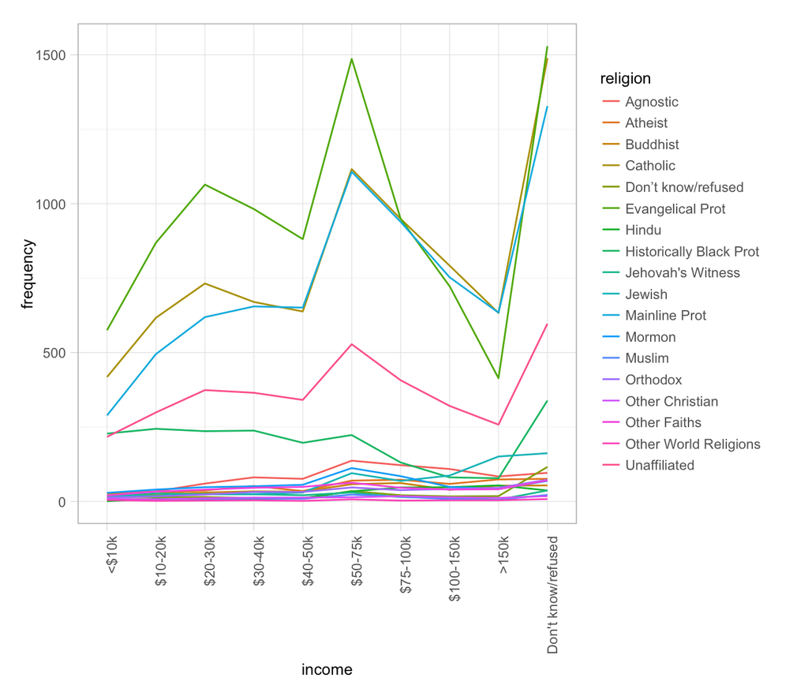

```r
library(ggplot2)
ggplot(pew_tidy, aes(x = income, y = frequency, color = religion,
  group = religion)) +
  geom_line() +
  theme(axis.text.x = element_text(angle = 90, hjust = 1))
```

Podemos hacer gráficas más interesantes si creamos nuevas variables:

```r
# explicaremos el operador %>% más adelante
by_religion <- group_by(pew_tidy, religion)
pew_tidy_2 <- pew_tidy %>%
  filter(income != "Don't know/refused") %>%
  group_by(religion) %>%
  mutate(percent = frequency / sum(frequency)) %>%
  filter(sum(frequency) > 1000)

head(pew_tidy_2)
```

```
Source: local data frame [6 x 4]
Groups: religion [5]

                 religion  income frequency percent
                    (chr)  (fctr)     (int)   (dbl)
1                Catholic   <$10k       418 0.06367
2        Evangelical Prot   <$10k       575 0.07239
3 Historically Black Prot   <$10k       228 0.13768
4           Mainline Prot   <$10k       289 0.04705
5            Unaffiliated   <$10k       217 0.06977
6                Catholic $10-20k       617 0.09398
```

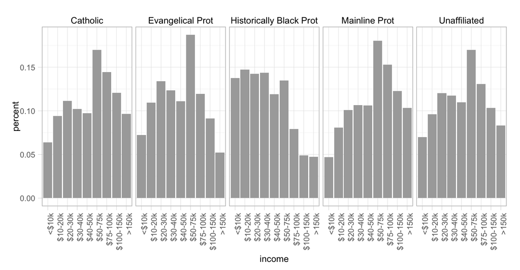

```r
ggplot(pew_tidy_2, aes(x = income, y = percent, group = religion)) +
  facet_wrap(~ religion, nrow = 1) +
  geom_bar(stat = "identity", fill = "darkgray") +
  theme(axis.text.x = element_text(angle = 90, hjust = 1))
```

En el código de arriba utilizamos las funciones `group_by`, `filter` y `mutate` que estudiaremos más adelante. Por ahora concentremonos en `gather` y `spread`.

Otro ejemplo, veamos los datos de *Billboard*, aquí se registra la fecha en la que una canción entra por primera vez al top 100 de Billboard.

```r
library(readr)
billboard <- read_csv("data/billboard.csv")
billboard
```

```
Source: local data frame [317 x 81]

    year         artist                   track  time date.entered   wk1
   (int)          (chr)                   (chr) (chr)       (date) (int)
1   2000          2 Pac Baby Don't Cry (Keep...  4:22   2000-02-26    87
2   2000        2Ge+her The Hardest Part Of ...  3:15   2000-09-02    91
3   2000   3 Doors Down              Kryptonite  3:53   2000-04-08    81
4   2000   3 Doors Down                   Loser  4:24   2000-10-21    76
5   2000       504 Boyz           Wobble Wobble  3:35   2000-04-15    57
6   2000           98^0 Give Me Just One Nig...  3:24   2000-08-19    51
7   2000        A*Teens           Dancing Queen  3:44   2000-07-08    97
8   2000        Aaliyah           I Don't Wanna  4:15   2000-01-29    84
9   2000        Aaliyah               Try Again  4:03   2000-03-18    59
10  2000 Adams, Yolanda           Open My Heart  5:30   2000-08-26    76
..   ...            ...                     ...   ...          ...   ...
Variables not shown: wk2 (int), wk3 (int), wk4 (int), wk5 (int), wk6
  (int), wk7 (int), wk8 (int), wk9 (int), wk10 (int), wk11 (int), wk12
  (int), wk13 (int), wk14 (int), wk15 (int), wk16 (int), wk17 (int), wk18
  (int), wk19 (int), wk20 (int), wk21 (int), wk22 (int), wk23 (int), wk24
  (int), wk25 (int), wk26 (int), wk27 (int), wk28 (int), wk29 (int), wk30
  (int), wk31 (int), wk32 (int), wk33 (int), wk34 (int), wk35 (int), wk36
  (int), wk37 (int), wk38 (int), wk39 (int), wk40 (int), wk41 (int), wk42
  (int), wk43 (int), wk44 (int), wk45 (int), wk46 (int), wk47 (int), wk48
  (int), wk49 (int), wk50 (int), wk51 (int), wk52 (int), wk53 (int), wk54
  (int), wk55 (int), wk56 (int), wk57 (int), wk58 (int), wk59 (int), wk60
  (int), wk61 (int), wk62 (int), wk63 (int), wk64 (int), wk65 (int), wk66
  (chr), wk67 (chr), wk68 (chr), wk69 (chr), wk70 (chr), wk71 (chr), wk72
  (chr), wk73 (chr), wk74 (chr), wk75 (chr), wk76 (chr)
```

Para tener datos *limpios* apilamos las semanas de manera que sea una sola columna (nuevamente alargamos los datos):

```r
billboard_long <- gather(billboard, week, rank, wk1:wk76, na.rm = TRUE)
billboard_long
```

```
Source: local data frame [5,307 x 7]

    year         artist                   track  time date.entered   week
   (int)          (chr)                   (chr) (chr)       (date) (fctr)
1   2000          2 Pac Baby Don't Cry (Keep...  4:22   2000-02-26    wk1
2   2000        2Ge+her The Hardest Part Of ...  3:15   2000-09-02    wk1
3   2000   3 Doors Down              Kryptonite  3:53   2000-04-08    wk1
4   2000   3 Doors Down                   Loser  4:24   2000-10-21    wk1
5   2000       504 Boyz           Wobble Wobble  3:35   2000-04-15    wk1
6   2000           98^0 Give Me Just One Nig...  3:24   2000-08-19    wk1
7   2000        A*Teens           Dancing Queen  3:44   2000-07-08    wk1
8   2000        Aaliyah           I Don't Wanna  4:15   2000-01-29    wk1
9   2000        Aaliyah               Try Again  4:03   2000-03-18    wk1
10  2000 Adams, Yolanda           Open My Heart  5:30   2000-08-26    wk1
..   ...            ...                     ...   ...          ...    ...
Variables not shown: rank (chr)
```

Notemos que en esta ocasión especificamos las columnas que vamos a apilar indicando el nombre de la primera de ellas seguido de `:` y por último el nombre de la última variable a apilar. Por otra parte, la instrucción `na.rm = TRUE` se utiliza para eliminar los renglones con valores faltantes en la columna de value (rank), esto es, eliminamos aquellas observaciones que tenían NA en la columnas wk*num* de la tabla ancha. Ahora realizamos una limpieza adicional creando mejores variables de fecha.

```r
billboard_tidy <- billboard_long %>%
  mutate(
    week = extract_numeric(week),
    date = date.entered + 7 * (week - 1),
    rank = as.numeric(rank)
    ) %>%
    select(-date.entered)
billboard_tidy
```

```
Source: local data frame [5,307 x 7]

    year         artist                   track  time  week  rank
   (int)          (chr)                   (chr) (chr) (dbl) (dbl)
1   2000          2 Pac Baby Don't Cry (Keep...  4:22     1    87
2   2000        2Ge+her The Hardest Part Of ...  3:15     1    91
3   2000   3 Doors Down              Kryptonite  3:53     1    81
4   2000   3 Doors Down                   Loser  4:24     1    76
5   2000       504 Boyz           Wobble Wobble  3:35     1    57
6   2000           98^0 Give Me Just One Nig...  3:24     1    51
7   2000        A*Teens           Dancing Queen  3:44     1    97
8   2000        Aaliyah           I Don't Wanna  4:15     1    84
9   2000        Aaliyah               Try Again  4:03     1    59
10  2000 Adams, Yolanda           Open My Heart  5:30     1    76
..   ...            ...                     ...   ...   ...   ...
Variables not shown: date (date)
```

Nuevamente, es fácil hacer graficas.

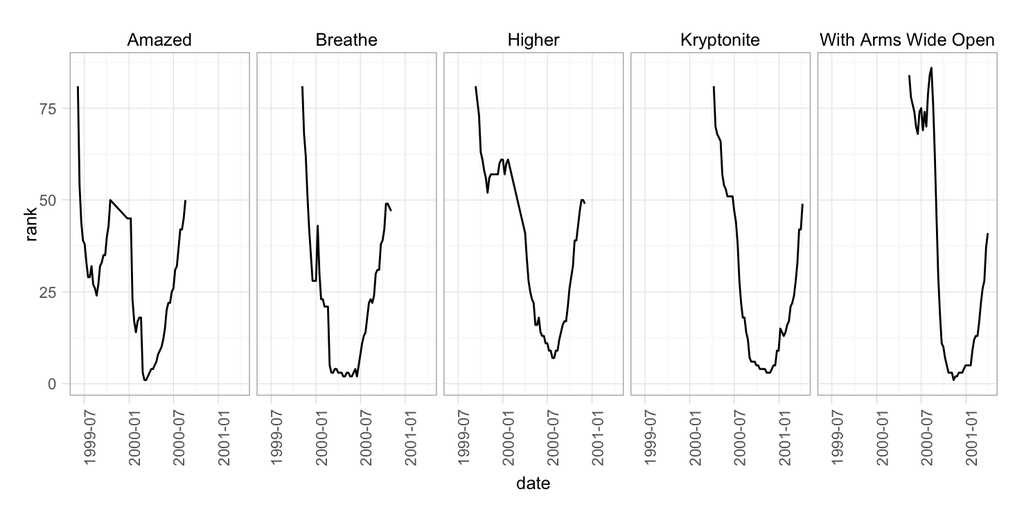

```r
tracks <- filter(billboard_tidy, track %in%
    c("Higher", "Amazed", "Kryptonite", "Breathe", "With Arms Wide Open"))

ggplot(tracks, aes(x = date, y = rank)) +
  geom_line() +
  facet_wrap(~track, nrow = 1) +
  theme(axis.text.x = element_text(angle = 90, hjust = 1))
```

#### 2. Una columna asociada a más de una variable

La siguiente base de datos proviene de la Organización Mundial de la Salud y contiene el número de casos confirmados de tuberculosis por país y año, la información esta por grupo demográfico de acuerdo a sexo (m, f), y edad (0-4, 5-14, etc).

```r
tb <- read_csv("data/tb.csv")
tb
```

```
Source: local data frame [5,769 x 23]

      id  iso2  year new_sp_m04 new_sp_m514 new_sp_m014 new_sp_m1524
   (int) (chr) (int)      (int)       (int)       (int)        (int)
1      1    AD  1989         NA          NA          NA           NA
2      2    AD  1990         NA          NA          NA           NA
3      3    AD  1991         NA          NA          NA           NA
4      4    AD  1992         NA          NA          NA           NA
5      5    AD  1993         NA          NA          NA           NA
6      6    AD  1994         NA          NA          NA           NA
7      7    AD  1996         NA          NA           0            0
8      8    AD  1997         NA          NA           0            0
9      9    AD  1998         NA          NA           0            0
10    10    AD  1999         NA          NA           0            0
..   ...   ...   ...        ...         ...         ...          ...
Variables not shown: new_sp_m2534 (int), new_sp_m3544 (int), new_sp_m4554
  (int), new_sp_m5564 (int), new_sp_m65 (int), new_sp_mu (int), new_sp_f04
  (int), new_sp_f514 (int), new_sp_f014 (int), new_sp_f1524 (int),
  new_sp_f2534 (int), new_sp_f3544 (int), new_sp_f4554 (int), new_sp_f5564
  (int), new_sp_f65 (int), new_sp_fu (int)
```

De manera similar a los ejemplos anteriores, utiliza la función `gather` para apilar las columnas correspondientes a sexo-edad.

Piensa en como podemos separar la “variable” sexo-edad en dos columnas.

[output not shown]

Ahora separaremos las variables sexo y edad de la columna demo, para ello debemos pasar a la función `separate`, esta recibe como parámetros:

- el nombre de la base de datos,
- el nombre de la variable que deseamos separar en más de una,
- la posición de donde deseamos “cortar” (hay más opciones para especificar como separar, ver `?separate`)

```r
tb_tidy <- separate(tb_long, demo, c("sex", "age"), 8)
tb_tidy
```

```
Source: local data frame [35,750 x 6]

      id  iso2  year      sex   age     n
   (int) (chr) (int)    (chr) (chr) (int)
1     16    AD  2005 new_sp_m    04     0
2     17    AD  2006 new_sp_m    04     0
3     19    AD  2008 new_sp_m    04     0
4     43    AE  2006 new_sp_m    04     0
5     44    AE  2007 new_sp_m    04     0
6     45    AE  2008 new_sp_m    04     0
7     95    AG  2007 new_sp_m    04     0
8    142    AL  2005 new_sp_m    04     0
9    143    AL  2006 new_sp_m    04     1
10   144    AL  2007 new_sp_m    04     0
..   ...   ...   ...      ...   ...   ...
```

```r
table(tb_tidy$sex)
```

```
new_sp_f new_sp_m
   17830    17920
```

```r
# creamos un mejor código de genero
tb_tidy <- mutate(tb_tidy, sex = substr(sex, 8, 8))
table(tb_tidy$sex)
```

```
    f     m
17830 17920
```

#### 3. Variables almacenadas en filas y columnas

El problema más difícil es cuando las variables están tanto en filas como en columnas, veamos una base de datos de clima en Cuernavaca. ¿Cuáles son las variables en estos datos?

```r
clima <- tbl_df(read.delim("data/clima.txt", stringsAsFactors=FALSE))
clima
```

```
Source: local data frame [22 x 35]

            id  year month element    d1    d2    d3    d4    d5    d6
         (chr) (int) (int)   (chr) (int) (int) (int) (int) (int) (int)
1  MX000017004  2010     1    TMAX    NA    NA    NA    NA    NA    NA
2  MX000017004  2010     1    TMIN    NA    NA    NA    NA    NA    NA
3  MX000017004  2010     2    TMAX    NA   273   241    NA    NA    NA
4  MX000017004  2010     2    TMIN    NA   144   144    NA    NA    NA
5  MX000017004  2010     3    TMAX    NA    NA    NA    NA   321    NA
6  MX000017004  2010     3    TMIN    NA    NA    NA    NA   142    NA
7  MX000017004  2010     4    TMAX    NA    NA    NA    NA    NA    NA
8  MX000017004  2010     4    TMIN    NA    NA    NA    NA    NA    NA
9  MX000017004  2010     5    TMAX    NA    NA    NA    NA    NA    NA
10 MX000017004  2010     5    TMIN    NA    NA    NA    NA    NA    NA
..         ...   ...   ...     ...   ...   ...   ...   ...   ...   ...
Variables not shown: d7 (int), d8 (int), d9 (lgl), d10 (int), d11 (int),
  d12 (lgl), d13 (int), d14 (int), d15 (int), d16 (int), d17 (int), d18
  (lgl), d19 (lgl), d20 (lgl), d21 (lgl), d22 (lgl), d23 (int), d24 (lgl),
  d25 (int), d26 (int), d27 (int), d28 (int), d29 (int), d30 (int), d31
  (int)
```

Estos datos tienen variables en columnas individuales (id, año, mes), en múltiples columnas (día, d1-d31) y en filas (tmin, tmax). Comencemos por apilar las columnas.

```r
clima_long <- gather(clima, day, value, d1:d31, na.rm = TRUE)
head(clima_long)
```

```
Source: local data frame [6 x 6]

           id  year month element    day value
        (chr) (int) (int)   (chr) (fctr) (int)
1 MX000017004  2010    12    TMAX     d1   299
2 MX000017004  2010    12    TMIN     d1   138
3 MX000017004  2010     2    TMAX     d2   273
4 MX000017004  2010     2    TMIN     d2   144
5 MX000017004  2010    11    TMAX     d2   313
6 MX000017004  2010    11    TMIN     d2   163
```

Podemos crear algunas variables adicionales.

```r
clima_vars <- clima_long %>%
  mutate(day = extract_numeric(day), value = value / 10)  %>%
  select(id, year, month, day, element, value) %>%
  arrange(id, year, month, day)
head(clima_vars)
```

```
Source: local data frame [6 x 6]

           id  year month   day element value
        (chr) (int) (int) (dbl)   (chr) (dbl)
1 MX000017004  2010     1    30    TMAX  27.8
2 MX000017004  2010     1    30    TMIN  14.5
3 MX000017004  2010     2     2    TMAX  27.3
4 MX000017004  2010     2     2    TMIN  14.4
5 MX000017004  2010     2     3    TMAX  24.1
6 MX000017004  2010     2     3    TMIN  14.4
```

Finalmente, la columna *element* no es una variable, sino que almacena el nombre de dos variables, la operación que debemos aplicar (spread) es el inverso de apilar (`gather`):

```r
clima_tidy <- spread(clima_vars, element, value)
head(clima_tidy)
```

```
Source: local data frame [6 x 6]

           id  year month   day  TMAX  TMIN
        (chr) (int) (int) (dbl) (dbl) (dbl)
1 MX000017004  2010     1    30  27.8  14.5
2 MX000017004  2010     2     2  27.3  14.4
3 MX000017004  2010     2     3  24.1  14.4
4 MX000017004  2010     2    11  29.7  13.4
5 MX000017004  2010     2    23  29.9  10.7
6 MX000017004  2010     3     5  32.1  14.2
```

Ahora es inmediato no solo hacer gráficas sino también ajustar un modelo.

```r
# ajustamos un modelo lineal donde la variable respuesta es temperatura
# máxima, y la variable explicativa es el mes
clima_lm <- lm(TMAX ~ factor(month), data = clima_tidy)
summary(clima_lm)
```

```
Call:
lm(formula = TMAX ~ factor(month), data = clima_tidy)

Residuals:
   Min     1Q Median     3Q    Max
 -3.65  -0.92  -0.02   1.05   3.18

Coefficients:
                Estimate Std. Error t value Pr(>|t|)
(Intercept)       27.800      1.861   14.94  5.3e-13 ***
factor(month)2    -0.050      2.081   -0.02   0.9810
factor(month)3     4.767      2.149    2.22   0.0372 *
factor(month)4     8.500      2.632    3.23   0.0039 **
factor(month)5     5.400      2.632    2.05   0.0523 .
factor(month)6     1.250      2.279    0.55   0.5889
factor(month)7     1.450      2.279    0.64   0.5312
factor(month)8     0.471      1.990    0.24   0.8149
factor(month)10    1.100      2.039    0.54   0.5949
factor(month)11    0.320      2.039    0.16   0.8767
factor(month)12    1.050      2.279    0.46   0.6496
---
Signif. codes:  0 '***' 0.001 '**' 0.01 '*' 0.05 '.' 0.1 ' ' 1

Residual standard error: 1.86 on 22 degrees of freedom
Multiple R-squared:  0.618, Adjusted R-squared:  0.445
F-statistic: 3.56 on 10 and 22 DF,  p-value: 0.0062
```

#### 4. Mas de un tipo de observación en una misma tabla

En ocasiones las bases de datos involucran valores en diferentes niveles, en diferentes tipos de unidad observacional. En la limpieza de datos, cada unidad observacional debe estar almacenada en su propia tabla (esto esta ligado a normalización de una base de datos), es importante para evitar inconsistencias en los datos.

¿Cuáles son las unidades observacionales de los datos de billboard?

```r
billboard_tidy
```

```
Source: local data frame [5,307 x 7]

    year         artist                   track  time  week  rank
   (int)          (chr)                   (chr) (chr) (dbl) (dbl)
1   2000          2 Pac Baby Don't Cry (Keep...  4:22     1    87
2   2000        2Ge+her The Hardest Part Of ...  3:15     1    91
3   2000   3 Doors Down              Kryptonite  3:53     1    81
4   2000   3 Doors Down                   Loser  4:24     1    76
5   2000       504 Boyz           Wobble Wobble  3:35     1    57
6   2000           98^0 Give Me Just One Nig...  3:24     1    51
7   2000        A*Teens           Dancing Queen  3:44     1    97
8   2000        Aaliyah           I Don't Wanna  4:15     1    84
9   2000        Aaliyah               Try Again  4:03     1    59
10  2000 Adams, Yolanda           Open My Heart  5:30     1    76
..   ...            ...                     ...   ...   ...   ...
Variables not shown: date (date)
```

Separemos esta base de datos en dos: la tabla canción que almacena artista, nombre de la canción y duración; la tabla rank que almacena el ranking de la canción en cada semana.

```r
song <- billboard_tidy %>%
  select(artist, track, year, time) %>%
  unique() %>%
  arrange(artist) %>%
  mutate(song_id = row_number(artist))
song
```

```
Source: local data frame [317 x 5]

           artist                   track  year  time song_id
            (chr)                   (chr) (int) (chr)   (int)
1           2 Pac Baby Don't Cry (Keep...  2000  4:22       1
2         2Ge+her The Hardest Part Of ...  2000  3:15       2
3    3 Doors Down              Kryptonite  2000  3:53       3
4    3 Doors Down                   Loser  2000  4:24       4
5        504 Boyz           Wobble Wobble  2000  3:35       5
6            98^0 Give Me Just One Nig...  2000  3:24       6
7         A*Teens           Dancing Queen  2000  3:44       7
8         Aaliyah           I Don't Wanna  2000  4:15       8
9         Aaliyah               Try Again  2000  4:03       9
10 Adams, Yolanda           Open My Heart  2000  5:30      10
..            ...                     ...   ...   ...     ...
```

```r
rank <- billboard_tidy %>%
  left_join(song, c("artist", "track", "year", "time")) %>%
  select(song_id, date, week, rank) %>%
  arrange(song_id, date) %>%
  tbl_df
rank
```

```
Source: local data frame [5,307 x 4]

   song_id       date  week  rank
     (int)     (date) (dbl) (dbl)
1        1 2000-02-26     1    87
2        1 2000-03-04     2    82
3        1 2000-03-11     3    72
4        1 2000-03-18     4    77
5        1 2000-03-25     5    87
6        1 2000-04-01     6    94
7        1 2000-04-08     7    99
8        2 2000-09-02     1    91
9        2 2000-09-09     2    87
10       2 2000-09-16     3    92
..     ...        ...   ...   ...
```

#### 5. Una misma unidad observacional está almacenada en múltiples tablas

También es común que los valores sobre una misma unidad observacional estén separados en muchas tablas o archivos, es común que estas tablas esten divididas de acuerdo a una variable, de tal manera que cada archivo representa a una persona, año o ubicación. Para juntar los archivos hacemos lo siguiente:

1. Leemos los archivos en una lista de tablas.
2. Para cada tabla agregamos una columna que registra el nombre del archivo original.
3. Combinamos las tablas en un solo data frame.

Veamos un ejemplo, descarga la carpeta [specdata](https://www.dropbox.com/sh/c0mgho95gwjc1mv/AACVLPr33O6ENW68xmL7hyUna?dl=0), ésta contiene 332 archivos csv que almacenan información de monitoreo de contaminación en 332 ubicaciones de EUA. Cada archivo contiene información de una unidad de monitoreo y el número de identificación del monitor es el nombre del archivo.

Los pasos en R (usando el paquete `plyr`), primero creamos un vector con los nombres de los archivos en un directorio, eligiendo aquellos que contengan las letras “.csv”.

```r
paths <- dir("data/specdata", pattern = "\\.csv$", full.names = TRUE)
```

Después le asignamos el nombre del csv al nombre de cada elemento del vector. Este paso se realiza para preservar los nmobres de los archivos ya que estos los asignaremos a una variable mas adelante.

```r
names(paths) <- basename(paths)
```

La función ldply del paquete plyr itera sobre cada dirección, lee el csv en dicha dirección y los combina en un data frame.

```r
library(plyr)
specdata_US <- ldply(paths, read_csv)
head(specdata_US)
```

```
      .id       Date sulfate nitrate ID
1 001.csv 2003-01-01      NA    <NA>  1
2 001.csv 2003-01-02      NA    <NA>  1
3 001.csv 2003-01-03      NA    <NA>  1
4 001.csv 2003-01-04      NA    <NA>  1
5 001.csv 2003-01-05      NA    <NA>  1
6 001.csv 2003-01-06      NA    <NA>  1
```

```r
# eliminamos la basura del id
specdata <- specdata_US %>%
  mutate(monitor = extract_numeric(.id)) %>%
  select(id = ID, monitor, date = Date, sulfate, nitrate)
head(specdata)
```

```
  id monitor       date sulfate nitrate
1  1       1 2003-01-01      NA    <NA>
2  1       1 2003-01-02      NA    <NA>
3  1       1 2003-01-03      NA    <NA>
4  1       1 2003-01-04      NA    <NA>
5  1       1 2003-01-05      NA    <NA>
6  1       1 2003-01-06      NA    <NA>
```

#### 6. Otras consideraciones

En las buenas prácticas es importante tomar en cuenta los siguientes puntos:

- Incluir un encabezado con el nombre de las variables.
- Los nombres de las variables deben ser entendibles (e.g. AgeAtDiagnosis es mejor que AgeDx).
- En general los datos se deben guardar en un archivo por tabla.
- Escribir un script con las modificaciones que se hicieron a los *datos crudos* (reproducibilidad).
- Otros aspectos importantes en la *limpieza* de datos son: selección del tipo de variables (por ejemplo fechas), datos faltantes, *typos* y detección de valores atípicos.

### Divide-aplica-combina (*split-apply-combine*)

Muchos problemas de análisis de datos involucran la aplicación de la estrategia divide-aplica-combina, ([Hadley Whickam, 2011](http://www.jstatsoft.org/v40/i01/paper)) esta consiste en romper un problema en pedazos (de acuerdo a una variable de interés), operar sobre cada subconjunto de manera independiente (ej. calcular la media de cada grupo, ordenar observaciones por grupo, estandarizar por grupo) y después unir los pedazos nuevamente. El siguiente diagrama ejemplifiaca el paradigma de divide-aplica-combina:

- **Separa** la base de datos original.
- **Aplica** funciones a cada subconjunto.
- **Combina** los resultados en una nueva base de datos.

[figure not shown]

En esta sección trabajaremos con las siguientes bases de datos para ejemplifcar las funciones de divide-aplica-combina:

```r
flights <- read_csv("data/flights.csv")
flights
```

```
Source: local data frame [227,496 x 14]

                  date  hour minute   dep   arr dep_delay arr_delay
                (time) (int)  (int) (int) (int)     (int)     (int)
1  2011-01-01 12:00:00    14      0  1400  1500         0       -10
2  2011-01-02 12:00:00    14      1  1401  1501         1        -9
3  2011-01-03 12:00:00    13     52  1352  1502        -8        -8
4  2011-01-04 12:00:00    14      3  1403  1513         3         3
5  2011-01-05 12:00:00    14      5  1405  1507         5        -3
6  2011-01-06 12:00:00    13     59  1359  1503        -1        -7
7  2011-01-07 12:00:00    13     59  1359  1509        -1        -1
8  2011-01-08 12:00:00    13     55  1355  1454        -5       -16
9  2011-01-09 12:00:00    14     43  1443  1554        43        44
10 2011-01-10 12:00:00    14     43  1443  1553        43        43
..                 ...   ...    ...   ...   ...       ...       ...
Variables not shown: carrier (chr), flight (int), dest (chr), plane (chr),
  cancelled (int), time (int), dist (int)
```

```r
weather <- read_csv("data/weather.csv")
weather
```

```
Source: local data frame [8,723 x 14]

         date  hour  temp dew_point humidity pressure visibility wind_dir
       (date) (int) (dbl)     (dbl)    (int)    (dbl)      (dbl)    (chr)
1  2011-01-01     0  59.0      28.9       32    29.86         10      NNE
2  2011-01-01     1  57.2      28.4       33    29.88         10      NNE
3  2011-01-01     2  55.4      28.4       36    29.93         10      NNW
4  2011-01-01     3  53.6      28.4       38    29.94         10    North
5  2011-01-01     4    NA        NA       NA    29.99         10      NNW
6  2011-01-01     5    NA        NA       NA    30.02         10    North
7  2011-01-01     6  53.1      17.1       24    30.05         10    North
8  2011-01-01     7  53.1      16.0       23    30.07         10    North
9  2011-01-01     8  54.0      18.0       24    30.09         10    North
10 2011-01-01     9  55.4      17.6       23    30.09         10      NNE
..        ...   ...   ...       ...      ...      ...        ...      ...
Variables not shown: wind_dir2 (int), wind_speed (dbl), gust_speed (dbl),
  precip (dbl), conditions (chr), events (chr)
```

```r
planes <- read_csv("data/planes.csv")
planes
```

```
Source: local data frame [2,853 x 9]

    plane  year               mfr          model no.eng no.seats speed
    (chr) (int)             (chr)          (chr)  (int)    (int) (int)
1  N576AA  1991 MCDONNELL DOUGLAS DC-9-82(MD-82)      2      172    NA
2  N557AA  1993        MARZ BARRY      KITFOX IV      1        2    NA
3  N403AA  1974             RAVEN           S55A     NA        1    60
4  N492AA  1989 MCDONNELL DOUGLAS DC-9-82(MD-82)      2      172    NA
5  N262AA  1985 MCDONNELL DOUGLAS DC-9-82(MD-82)      2      172    NA
6  N493AA  1989 MCDONNELL DOUGLAS DC-9-82(MD-82)      2      172    NA
7  N477AA  1988 MCDONNELL DOUGLAS DC-9-82(MD-82)      2      172    NA
8  N476AA  1988 MCDONNELL DOUGLAS DC-9-82(MD-82)      2      172    NA
9  N504AA    NA AUTHIER ANTHONY P      TIERRA II      1        2    NA
10 N565AA  1987 MCDONNELL DOUGLAS DC-9-83(MD-83)      2      172    NA
..    ...   ...               ...            ...    ...      ...   ...
Variables not shown: engine (chr), type (chr)
```

```r
airports <- read_csv("data/airports.csv")
airports
```

```
Source: local data frame [3,376 x 7]

    iata              airport             city state country   lat    long
   (chr)                (chr)            (chr) (chr)   (chr) (dbl)   (dbl)
1    00M              Thigpen      Bay Springs    MS     USA 31.95  -89.23
2    00R Livingston Municipal       Livingston    TX     USA 30.69  -95.02
3    00V          Meadow Lake Colorado Springs    CO     USA 38.95 -104.57
4    01G         Perry-Warsaw            Perry    NY     USA 42.74  -78.05
5    01J     Hilliard Airpark         Hilliard    FL     USA 30.69  -81.91
6    01M    Tishomingo County          Belmont    MS     USA 34.49  -88.20
7    02A           Gragg-Wade          Clanton    AL     USA 32.85  -86.61
8    02C              Capitol       Brookfield    WI     USA 43.09  -88.18
9    02G    Columbiana County   East Liverpool    OH     USA 40.67  -80.64
10   03D     Memphis Memorial          Memphis    MO     USA 40.45  -92.23
..   ...                  ...              ...   ...     ...   ...     ...
```

Cuando pensamos como implementar la estrategia divide-aplica-combina es natural pensar en iteraciones, por ejemplo utilizar un ciclo *for* para recorrer cada grupo de interés y aplicar las funciones, sin embargo la aplicación de ciclos *for* desemboca en código difícil de entender. Adicionalmente, dplyr es mucho más veloz.

Estudiaremos las siguientes funciones:

- **filter**: obten un subconjunto de las filas de acuerdo a un criterio.
- **select**: selecciona columnas de acuerdo al nombre
- **arrange**: reordena las filas
- **mutate**: agrega nuevas variables
- **summarise**: reduce variables a valores (crear nuevas bases de datos)

Estas funciones trabajan de manera similar, el primer argumento que reciben es un *data frame* (usualmente en formato *limpio*), los argumentos que siguen indican que operación se va a efectuar y el resultado es un nuevo *data frame*.

Veamos con ejemplos.

#### Filtrar

Creamos una base de datos de juguete para mostrar el funcionamiento de cada instrucción:

```r
df_ej <- data_frame(genero = c("mujer", "hombre", "mujer", "mujer", "hombre"),
  estatura = c(1.65, 1.80, 1.70, 1.60, 1.67))
df_ej
```

```
Source: local data frame [5 x 2]

  genero estatura
   (chr)    (dbl)
1  mujer     1.65
2 hombre     1.80
3  mujer     1.70
4  mujer     1.60
5 hombre     1.67
```

```r
filter(df_ej, genero == "mujer")
```

```
Source: local data frame [3 x 2]

  genero estatura
   (chr)    (dbl)
1  mujer     1.65
2  mujer     1.70
3  mujer     1.60
```

```r
filter(df_ej, estatura > 1.65 & estatura < 1.75)
```

```
Source: local data frame [2 x 2]

  genero estatura
   (chr)    (dbl)
1  mujer     1.70
2 hombre     1.67
```

Algunos operadores importantes para filtrar son:

```r
x > 1
x >= 1
x < 1
x <= 1
x != 1
x == 1
x %in% ("a", "b")

# Conjuntos
a | b
a & b
a & !b
xor(a, b)
```

Encuentra todos los vuelos hacia SFO ó OAK.

Los vuelos con un retraso mayor a una hora.

En los que el retraso de llegada es más del doble que el retraso de salida.

#### Seleccionar

Elegir columnas de un conjunto de datos.

```r
library(dplyr)
df_ej
```

```
Source: local data frame [5 x 2]

  genero estatura
   (chr)    (dbl)
1  mujer     1.65
2 hombre     1.80
3  mujer     1.70
4  mujer     1.60
5 hombre     1.67
```

```r
select(df_ej, genero)
```

```
Source: local data frame [5 x 1]

  genero
   (chr)
1  mujer
2 hombre
3  mujer
4  mujer
5 hombre
```

```r
select(df_ej, -genero)
```

```
Source: local data frame [5 x 1]

  estatura
     (dbl)
1     1.65
2     1.80
3     1.70
4     1.60
5     1.67
```

```r
select(df_ej, starts_with("g"))
select(df_ej, contains("g"))
```

Ve la ayuda de select (`?select`) y escribe tres maneras de seleccionar las variables de retraso (delay).

#### Arreglar

Arreglar u ordenar de acuerdo al valor de una o más variables:

```r
arrange(df_ej, genero)
```

```
Source: local data frame [5 x 2]

  genero estatura
   (chr)    (dbl)
1 hombre     1.80
2 hombre     1.67
3  mujer     1.65
4  mujer     1.70
5  mujer     1.60
```

```r
arrange(df_ej, desc(estatura))
```

```
Source: local data frame [5 x 2]

  genero estatura
   (chr)    (dbl)
1 hombre     1.80
2  mujer     1.70
3 hombre     1.67
4  mujer     1.65
5  mujer     1.60
```

Ordena los vuelos por fecha de salida y hora.

¿Cuáles son los vuelos con mayor retraso?

¿Qué vuelos *ganaron* más tiempo en el aire?

#### Mutar

Mutar consiste en crear nuevas variables:

```r
mutate(df_ej, estatura_cm = estatura * 100)
```

```
Source: local data frame [5 x 3]

  genero estatura estatura_cm
   (chr)    (dbl)       (dbl)
1  mujer     1.65         165
2 hombre     1.80         180
3  mujer     1.70         170
4  mujer     1.60         160
5 hombre     1.67         167
```

```r
mutate(df_ej, estatura_cm = estatura * 100, estatura_in = estatura_cm * 0.3937)
```

```
Source: local data frame [5 x 4]

  genero estatura estatura_cm estatura_in
   (chr)    (dbl)       (dbl)       (dbl)
1  mujer     1.65         165       64.96
2 hombre     1.80         180       70.87
3  mujer     1.70         170       66.93
4  mujer     1.60         160       62.99
5 hombre     1.67         167       65.75
```

Calcula la velocidad en millas por hora a partir de la variable tiempo y la distancia (en millas). ¿Quá vuelo fue el más rápido?

Crea una nueva variable que muestre cuánto tiempo se ganó o perdió durante el vuelo.

#### Summarise y resúmenes por grupo

Summarise sirve para crear nuevas bases de datos con resúmenes o agregaciones de los datos originales.

```r
summarise(df_ej, promedio = mean(estatura))
```

```
Source: local data frame [1 x 1]

  promedio
     (dbl)
1    1.684
```

Podemos hacer resúmenes por grupo, primero creamos una base de datos agrupada:

```r
by_genero <- group_by(df_ej, genero)
by_genero
```

```
Source: local data frame [5 x 2]
Groups: genero [2]

  genero estatura
   (chr)    (dbl)
1  mujer     1.65
2 hombre     1.80
3  mujer     1.70
4  mujer     1.60
5 hombre     1.67
```

y después operamos sobre cada grupo, creando un resumen a nivel grupo y uniendo los subconjuntos en una base nueva:

```r
summarise(by_genero, promedio = mean(estatura))
```

```
Source: local data frame [2 x 2]

  genero promedio
   (chr)    (dbl)
1 hombre    1.735
2  mujer    1.650
```

Calcula el retraso promedio por fecha.

¿Qué otros resúmenes puedes hacer para explorar el retraso por fecha?

- Algunas funciones útiles con *summarise* son min(x), median(x), max(x), quantile(x, p), n(), sum(x), sum(x > 1), mean(x > 1), sd(x).

```r
flights$date_only <- as.Date(flights$date)
by_date <- group_by(flights, date_only)
no_miss <- filter(by_date, !is.na(dep))
delays <- summarise(no_miss, mean_delay = mean(dep_delay), n = n())
```

#### Operador pipeline

Cuando uno hace varias operaciones es difícil leer y entender el código:

```r
hourly_delay <- filter(summarise(group_by(filter(flights, !is.na(dep_delay)),
  date_only, hour), delay = mean(dep_delay), n = n()), n > 10)
```

La dificultad radica en que usualmente los parámetros se asignan después del nombre de la función usando (). El operador “Forward Pipe” (%>%) cambia este orden, manera que un parámetro que precede a la función es enviado (“piped”) a la función.

Veamos como cambia el código anterior:

```r
hourly_delay <- flights %>%
  filter(!is.na(dep_delay)) %>%
  group_by(date_only, hour) %>%
  summarise(delay = mean(dep_delay), n = n()) %>%
  filter(n > 10)
```

podemos leer %>% como “*después*”.

¿Qué destinos tienen el promedio de retrasos más alto?

¿Qué vuelos (compañía + vuelo) ocurren diario?

En promedio, ¿Cómo varían a lo largo del día los retrasos de vuelos no cancelados? (pista: hour + minute / 60)

#### Variables por grupo

En ocasiones es conveniente crear variables por grupo, por ejemplo estandarizar dentro de cada grupo z = (x - mean(x)) / sd(x).

Veamos un ejemplo:

```r
planes <- flights %>%
  filter(!is.na(arr_delay)) %>%
  group_by(plane) %>%
  filter(n() > 30)

planes %>%
  mutate(z_delay =
    (arr_delay - mean(arr_delay)) / sd(arr_delay)) %>%
  filter(z_delay > 5)
```

```
Source: local data frame [1,403 x 16]
Groups: plane [856]

                  date  hour minute   dep   arr dep_delay arr_delay
                (time) (int)  (int) (int) (int)     (int)     (int)
1  2011-01-28 12:00:00    15     16  1516  1916       351       326
2  2011-01-27 12:00:00    18     22  1822  1945       234       210
3  2011-01-27 12:00:00    21     37  2137  2254       242       219
4  2011-01-27 12:00:00     0     11    11   216       168       137
5  2011-01-27 12:00:00    22     37  2237   153       227       208
6  2011-01-27 12:00:00    21     28  2128   136       231       216
7  2011-01-26 12:00:00    11     46  1146  1633       171       193
8  2011-01-26 12:00:00     9     49   949  1436       144       180
9  2011-01-21 12:00:00    19     11  1911  2352        94       112
10 2011-01-20 12:00:00     6     35   635   807       780       775
..                 ...   ...    ...   ...   ...       ...       ...
Variables not shown: carrier (chr), flight (int), dest (chr), plane (chr),
  cancelled (int), time (int), dist (int), date_only (date), z_delay (dbl)
```

#### Verbos de dos tablas

¿Cómo mostramos los retrasos de los vuelos en un mapa?

Para responder esta pregunta necesitamos unir la base de datos de vuelos con la de aeropuertos.

```r
location <- airports %>%
  select(dest = iata, name = airport, lat, long)

flights %>%
  group_by(dest) %>%
  filter(!is.na(arr_delay)) %>%
  summarise(
    arr_delay = mean(arr_delay),
    n = n() ) %>%
    arrange(desc(arr_delay)) %>%
    left_join(location) %>%
    tbl_df
```

```
Source: local data frame [116 x 6]

    dest arr_delay     n                                name   lat    long
   (chr)     (dbl) (int)                               (chr) (dbl)   (dbl)
1    ANC     26.08   124 Ted Stevens Anchorage International 61.17 -150.00
2    CID     17.80   406                        Eastern Iowa 41.88  -91.71
3    DSM     15.95   634            Des Moines International 41.53  -93.66
4    SFO     14.89  2800         San Francisco International 37.62 -122.37
5    BPT     14.33     3            Southeast Texas Regional 29.95  -94.02
6    GRR     13.72   665           Kent County International 42.88  -85.52
7    DAY     13.67   444             James M Cox Dayton Intl 39.90  -84.22
8    VPS     12.46   864                Eglin Air Force Base 30.48  -86.53
9    ECP     12.42   720                                  NA    NA      NA
10   SAV     12.33   851              Savannah International 32.13  -81.20
..   ...       ...   ...                                 ...   ...     ...
```

Hay varias maneras de unir dos bases de datos y debemos pensar en el obejtivo:

```r
x <- data_frame(name = c("John", "Paul", "George", "Ringo", "Stuart", "Pete"),
  instrument = c("guitar", "bass", "guitar", "drums", "bass",
     "drums"))

y <- data_frame(name = c("John", "Paul", "George", "Ringo", "Brian"),
  band = c("TRUE", "TRUE", "TRUE",  "TRUE", "FALSE"))
x
```

```
Source: local data frame [6 x 2]

    name instrument
   (chr)      (chr)
1   John     guitar
2   Paul       bass
3 George     guitar
4  Ringo      drums
5 Stuart       bass
6   Pete      drums
```

```r
y
```

```
Source: local data frame [5 x 2]

    name  band
   (chr) (chr)
1   John  TRUE
2   Paul  TRUE
3 George  TRUE
4  Ringo  TRUE
5  Brian FALSE
```

```r
inner_join(x, y)
```

```
Source: local data frame [4 x 3]

    name instrument  band
   (chr)      (chr) (chr)
1   John     guitar  TRUE
2   Paul       bass  TRUE
3 George     guitar  TRUE
4  Ringo      drums  TRUE
```

```r
left_join(x, y)
```

```
Source: local data frame [6 x 3]

    name instrument  band
   (chr)      (chr) (chr)
1   John     guitar  TRUE
2   Paul       bass  TRUE
3 George     guitar  TRUE
4  Ringo      drums  TRUE
5 Stuart       bass    NA
6   Pete      drums    NA
```

```r
semi_join(x, y)
```

```
Source: local data frame [4 x 2]

    name instrument
   (chr)      (chr)
1   John     guitar
2   Paul       bass
3 George     guitar
4  Ringo      drums
```

```r
anti_join(x, y)
```

```
Source: local data frame [2 x 2]

    name instrument
   (chr)      (chr)
1   Pete      drums
2 Stuart       bass
```

Resumamos lo que observamos arriba:

| Tipo | Acción |
| --- | --- |
| inner | Incluye únicamente las filas que aparecen tanto en x como en y |
| left | Incluye todas las filas en x y las filas de y que coincidan |
| semi | Incluye las filas de x que coincidan con y |
| anti | Incluye las filas de x que no coinciden con y |

Ahora combinamos datos a nivel hora con condiciones climáticas, ¿cuál es el tipo de unión adecuado?

```r
hourly_delay <- flights %>%
  group_by(date_only, hour) %>%
  filter(!is.na(dep_delay)) %>%
  summarise(
    delay = mean(dep_delay),
    n = n() ) %>%
  filter(n > 10)

delay_weather <- hourly_delay %>% left_join(weather)
arrange(delay_weather, -delay)
```

```
Source: local data frame [2,091,842 x 17]
Groups: date_only [365]

    date_only  hour delay     n       date  temp dew_point humidity
       (date) (int) (dbl) (int)     (date) (dbl)     (dbl)    (int)
1  2011-01-01    20 26.26    19 2011-01-02  48.9      28.9       46
2  2011-01-01    20 26.26    19 2011-01-03  43.0      25.0       49
3  2011-01-01    20 26.26    19 2011-01-04  54.0      45.0       72
4  2011-01-01    20 26.26    19 2011-01-05  60.8      60.8      100
5  2011-01-01    20 26.26    19 2011-01-06  60.1      37.9       44
6  2011-01-01    20 26.26    19 2011-01-07  52.0      33.1       49
7  2011-01-01    20 26.26    19 2011-01-08  54.0      43.0       66
8  2011-01-01    20 26.26    19 2011-01-09  53.1      43.0       69
9  2011-01-01    20 26.26    19 2011-01-10  44.6      39.2       81
10 2011-01-01    20 26.26    19 2011-01-11  41.0      35.6       81
..        ...   ...   ...   ...        ...   ...       ...      ...
Variables not shown: pressure (dbl), visibility (dbl), wind_dir (chr),
  wind_dir2 (int), wind_speed (dbl), gust_speed (dbl), precip (dbl),
  conditions (chr), events (chr)
```

¿Qué condiciones climáticas están asociadas con retrasos en las salidas de Houston?

Explora si los aviones más viejos están asociados a mayores retrasos, responde con una gráfica.

#### Métodos más generales (*Do*)

A diferencia de summarise, *do* es una función más lenta pero más general, resulta particularmente útil cuando se usa para ajustar un conjunto de modelos.

Veamos un ejemplo con la base de datos de bateo [Lahman](http://seanlahman.com/files/database/readme2012.txt). Agruparemos por año y ajustaremos un modelo para explorar la relación entre número de bateos y carreras.

```r
batting <- read_csv("data/batting.csv")

batting_center <- batting %>%
  group_by(yearID) %>%
  mutate(
    AB_center = AB - mean(AB, na.rm = TRUE)   # centramos dentro de cada grupo (año)
  )

models <- batting_center %>%
  group_by(yearID) %>%
  do(
    mod = lm(formula = R ~ AB_center, data = .)
  )
models
```

```
Source: local data frame [142 x 2]
Groups: <by row>

   yearID     mod
    (int)   (chr)
1    1871 <S3:lm>
2    1872 <S3:lm>
3    1873 <S3:lm>
4    1874 <S3:lm>
5    1875 <S3:lm>
6    1876 <S3:lm>
7    1877 <S3:lm>
8    1878 <S3:lm>
9    1879 <S3:lm>
10   1880 <S3:lm>
..    ...     ...
```

```r
models[[1, 'mod']]
```

```
Call:
lm(formula = R ~ AB_center, data = .)

Coefficients:
(Intercept)    AB_center
     23.122        0.269
```

Podemos extraer componentes de los objetos lm guerdados en la variable mod.

```r
models_r <- models %>%
  summarise(r.squared = summary(mod)$r.squared)

models_2 <- models %>%
  group_by(yearID) %>%
  do(data.frame(t(coef(.[[1, 'mod']])))) %>%
  mutate(intercept = X.Intercept.) %>%
  select(-X.Intercept.)
```

```
geom_smooth: method="auto" and size of largest group is <1000, so using loess. Use 'method = x' to change the smoothing method.
```

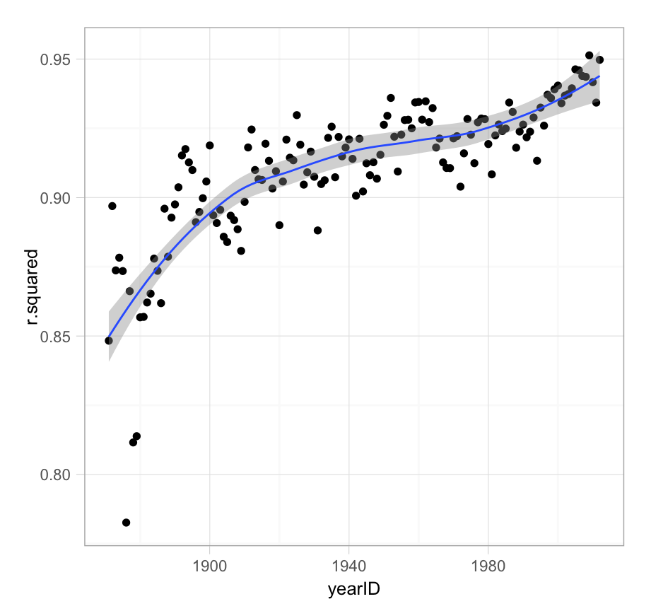

```r
models_3 <- cbind(models_2, models_r)


ggplot(models_3, aes(x = yearID, y = r.squared)) + geom_point() + geom_smooth()
```

Veamos las rectas de regresión.

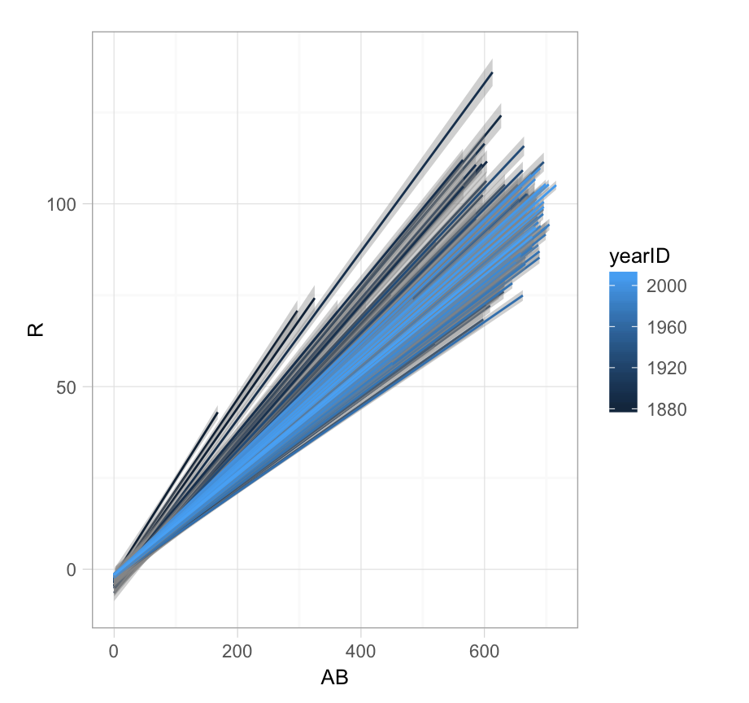

```r
ggplot(batting, aes(x = AB, y = R, color = yearID, group = yearID)) +
  geom_smooth(method = "lm")
```

Podemos comparar los coeficientes

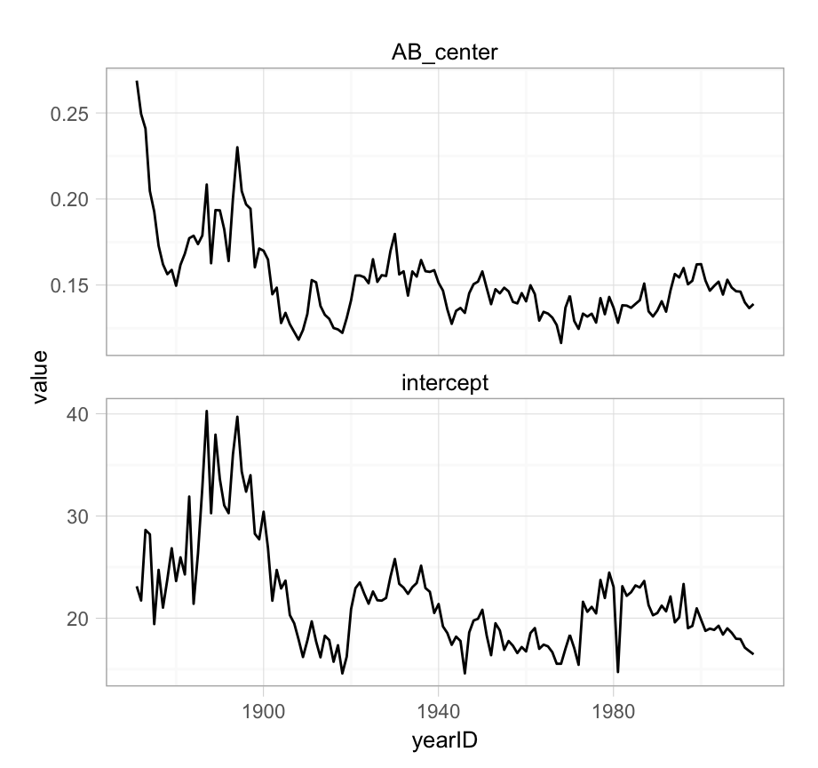

```r
models_3 <- gather(models_2, coef, value, -yearID)

ggplot(models_3, aes(x = yearID, y = value)) +
  geom_line() +
  facet_wrap(~ coef, scales = "free_y", nrow = 2)
```

Podemos ver las diferencias a nivel año en los datos crudos.

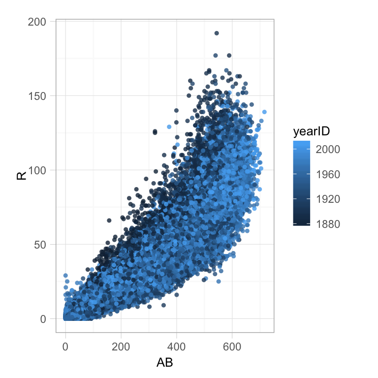

```r
ggplot(batting, aes(x = AB, y = R, color = yearID)) +
  geom_point(alpha = 0.8, size = 1.6)
```

Es conveniente usar el paquete biglm cuando se ajustan muchos modelos lineales, ya que guarda objetos de menor tamaño.

```r
library(biglm)
models_big <- batting %>%
  group_by(yearID) %>%
  do(
    mod = biglm(R ~ AB, data = .)
  )

print(object.size(models), unit = "MB")
```

```
22.7 Mb
```

```r
print(object.size(models_big), unit = "MB")
```

```
0.8 Mb
```

En la función *do* puede ser un poco complicado extraer las componentes de los objetos que ajustamos. Una alternativa es usar las funciones del paquete plyr (en particular ddply, ldply) o las funciones que vienen en R estándar (lapply, apply, tapply).

```r
models <- dlply(batting_center, "yearID", function(df){
  lm(R ~ AB_center, data = df)     # regresión lineal
})

models[[1]]
```

```
Call:
lm(formula = R ~ AB_center, data = df)

Coefficients:
(Intercept)    AB_center
     23.122        0.269
```

```r
coef_list <- lapply(models, coef)
head(do.call(rbind, coef_list))
```

```
     (Intercept) AB_center
1871       23.12    0.2688
1872       21.73    0.2494
1873       28.64    0.2409
1874       28.21    0.2047
1875       19.42    0.1927
1876       24.73    0.1729
```

### Expresiones regulares

Las expresiones regulares son patrones que se usan para encontrar determinas combinaciones de caracteres en un orden específico. La idea detras de las expresiones regulares es poder analizar gramaticalmente archivos de texto o texto en general. En nuestro contexto lo que buscamos es la extracción de datos de fuentes de texto diversas. Una expresión regular se puede pensar como una combinación de caracteres literales y meta caracteres. Los caracteres literales son de los que están formadas las palabras en el lenguaje utilizado.

#### Cuantificadores

- *: Cero o más ocurrencias del caracter anterior, por ejemplo 10*, va a aceptar las cadenas “1”, “10”, “100”, “1000”, etc
- +: Una o más ocurrencias del caracter anterior, por ejemplo 10+, va a aceptar las cadenas 10“,”100“,”1000“, etc, pero no la cadena”1"
- ?: Hasta una ocurrencia del caracter anterior, por ejemplo patos?, va aveptar las cadenas “pato” y “patos”
- {n}: Exactamente n veces el caracter anterior, por ejemplo 10{5}, únicamente va a aceptar la cadena “100000”
- {n,}: Mínimo n veces el caracter anterior, por ejemplo 10{5,}, aceptará las cadenas “100000”, “1000000”, “1000000”, etc
- {n,m}: Entre n y m veces el caracter anterior, por ejemplo 10{2,5}, aceptará las cadenas “100”, “10000”

#### Posicionadores

- ^: Inicio de la cadena, por ejemplo ^GAAA aceptará “GAAACCCTTT”, pero no “CCCTGAAAC”
- $: Fin de la cadena, por ejemplo TCCA$ aceptará “ACTTCCA” pero no “AGTCCATC”

### Expresiones regulares en R

Las expresiones regulares son independientes del lenguaje R, existe una implementación para prácticamente cualquier lenguaje de programación. En lo que nos compete en este curso, veremos los principales usos que se le pueden dar en la plataforma de interés. Para ejemplificar el uso de expresiones regulares en el lenguaje R se usarán datos procedentes de la siguiente página homicides

```r
homicides <- readLines("data/homicides.txt")
head(homicides)
```

```
[1] "39.311024, -76.674227, iconHomicideShooting, 'p2', '<dl><dt>Leon Nelson</dt><dd class=\"address\">3400 Clifton Ave.<br />Baltimore, MD 21216</dd><dd>black male, 17 years old</dd><dd>Found on January 1, 2007</dd><dd>Victim died at Shock Trauma</dd><dd>Cause: shooting</dd></dl>'"
[2] "39.312641, -76.698948, iconHomicideShooting, 'p3', '<dl><dt>Eddie Golf</dt><dd class=\"address\">4900 Challedon Road<br />Baltimore, MD 21207</dd><dd>black male, 26 years old</dd><dd>Found on January 2, 2007</dd><dd>Victim died at scene</dd><dd>Cause: shooting</dd></dl>'"
[3] "39.309781, -76.649882, iconHomicideBluntForce, 'p4', '<dl><dt>Nelsene Burnette</dt><dd class=\"address\">2000 West North Ave<br />Baltimore, MD 21217</dd><dd>black female, 44 years old</dd><dd>Found on January 2, 2007</dd><dd>Victim died at scene</dd><dd>Cause: blunt force</dd></dl>'"
[4] "39.363925, -76.598772, iconHomicideAsphyxiation, 'p5', '<dl><dt>Thomas MacKenney</dt><dd class=\"address\">5900 Northwood Drive<br />Baltimore, MD 21212</dd><dd>black male, 21 years old</dd><dd>Found on January 3, 2007</dd><dd>Victim died at scene</dd><dd>Cause: asphyxiation</dd></dl>'"
[5] "39.238928, -76.602718, iconHomicideBluntForce, 'p6', '<dl><dt>Edward Canupp</dt><dd class=\"address\">500 Maude Ave.<br />Baltimore, MD 21225</dd><dd>white male, 61 years old</dd><dd>Found on January 5, 2007</dd><dd>Victim died at scene</dd><dd>Cause: blunt force</dd></dl>'"
[6] "39.352676, -76.607979, iconHomicideShooting, 'p7', '<dl><dt>Michael Cunningham</dt><dd class=\"address\">5200 Ready Ave.<br />Baltimore, MD 21212</dd><dd>black male, 46 years old</dd><dd>Found on January 5, 2007</dd><dd>Victim died at JHH</dd><dd>Cause: shooting</dd></dl>'"
```

Podemos ver la naturaleza en la que vienen los datos.

```r
homicides[1]
```

```
[1] "39.311024, -76.674227, iconHomicideShooting, 'p2', '<dl><dt>Leon Nelson</dt><dd class=\"address\">3400 Clifton Ave.<br />Baltimore, MD 21216</dd><dd>black male, 17 years old</dd><dd>Found on January 1, 2007</dd><dd>Victim died at Shock Trauma</dd><dd>Cause: shooting</dd></dl>'"
```

```r
homicides[1000]
```

```
[1] "39.33626300000, -76.55553990000, icon_homicide_shooting, 'p1200', '<dl><dt><a href=\"http://essentials.baltimoresun.com/micro_sun/homicides/victim/1200/davon-diggs\">Davon Diggs</a></dt><dd class=\"address\">4100 Parkwood Ave<br />Baltimore, MD 21206</dd><dd>Race: Black<br />Gender: male<br />A…
```

#### grep, grepl

Las funciones grep y grepl, buscan las coincidencias del patrón (expresión regular), que se da como argumento. La función grep regresa los indices donde existió una coincidencia, la función grepl regresa una lista booleana donde las entradas son TRUE, cuando existe una coincidencia, FALSE cuando no hay tal. Usando la función grep podemos obtener el número de homicidios de nuestro dataset:

```r
length(grep("iconHomicideShooting", homicides))
```

```
[1] 228
```

```r
length(grep("iconHomicideShooting|icon_homicide_shooting", homicides))
```

```
[1] 1781
```

Usando otra sección de la información obtenemos:

```r
length(grep("Cause: shooting", homicides))
```

```
[1] 228
```

```r
length(grep("Cause: [Ss]hooting", homicides))
```

```
[1] 1781
```

Veamos que pasa si cambiamos el patrón de búsqueda:

```r
length(grep("[Ss]hooting", homicides))
```

```
[1] 1784
```

¿Como obtenemos las diferencias entre ambos resultados?

```r
i <- grep("[cC]ause: [sS]hooting", homicides)
j <- grep("[sS]hooting", homicides)
str(i)
```

```
 int [1:1781] 1 2 6 7 8 9 10 11 12 13 ...
```

```r
str(j)
```

```
 int [1:1784] 1 2 6 7 8 9 10 11 12 13 ...
```

```r
setdiff(i, j)
```

```
integer(0)
```

```r
setdiff(j, i)
```

```
[1]  318  859 2068
```

Analizando el resultado, vemos cual es la razón de dicha diferencia:

```r
homicides[318]
```

```
[1] "39.28322500000, -76.63946800000, icon_homicide_bluntforce, 'p472', '<dl><dt><a href=\"http://essentials.baltimoresun.com/micro_sun/homicides/victim/472/lyle-dimeler\">Lyle Dimeler</a></dt><dd class=\"address\">400 S. Calhoun St.<br />Baltimore, MD 21223</dd><dd>Race: Unknown<br />Gender: male<b…
```

```r
homicides[859]
```

```
[1] "39.33743900000, -76.66316500000, icon_homicide_bluntforce, 'p914', '<dl><dt><a href=\"http://essentials.baltimoresun.com/micro_sun/homicides/victim/914/steven-harris\">Steven Harris</a></dt><dd class=\"address\">4200 Pimlico Road<br />Baltimore, MD 21215</dd><dd>Race: Black<br />Gender: male<br…
```

```r
homicides[2068]
```

```
[1] "39.35350799561, -76.66704559326, icon_homicide_bluntforce, 'p2058', '<dl><dt><a href=\"http://data.baltimoresun.com/news/police/homicides/victim/2058/\">Jerod Richardson</a></dt><dd class=\"address\">2500 W. Belvedere Avenue<br />Baltimore, MD 21215</dd><dd>Race: Black<br />Gender: male<br />Ag…
```

Como ya se mencionó, podemos obtener los indices de las ocurrencias del patrón de interés, también podemos obtener los valores directamente, o un vector booleano con las coincidencias (verdadero o falso) del patrón dentro de nuestro vector de cadenas.

```r
state.name
```

```
 [1] "Alabama"        "Alaska"         "Arizona"        "Arkansas"
 [5] "California"     "Colorado"       "Connecticut"    "Delaware"
 [9] "Florida"        "Georgia"        "Hawaii"         "Idaho"
[13] "Illinois"       "Indiana"        "Iowa"           "Kansas"
[17] "Kentucky"       "Louisiana"      "Maine"          "Maryland"
[21] "Massachusetts"  "Michigan"       "Minnesota"      "Mississippi"
[25] "Missouri"       "Montana"        "Nebraska"       "Nevada"
[29] "New Hampshire"  "New Jersey"     "New Mexico"     "New York"
[33] "North Carolina" "North Dakota"   "Ohio"           "Oklahoma"
[37] "Oregon"         "Pennsylvania"   "Rhode Island"   "South Carolina"
[41] "South Dakota"   "Tennessee"      "Texas"          "Utah"
[45] "Vermont"        "Virginia"       "Washington"     "West Virginia"
[49] "Wisconsin"      "Wyoming"
```

```r
grep("^New", state.name)
```

```
[1] 29 30 31 32
```

```r
grep("^New", state.name, value =TRUE)
```

```
[1] "New Hampshire" "New Jersey"    "New Mexico"    "New York"
```

```r
grepl("^New", state.name)
```

```
 [1] FALSE FALSE FALSE FALSE FALSE FALSE FALSE FALSE FALSE FALSE FALSE
[12] FALSE FALSE FALSE FALSE FALSE FALSE FALSE FALSE FALSE FALSE FALSE
[23] FALSE FALSE FALSE FALSE FALSE FALSE  TRUE  TRUE  TRUE  TRUE FALSE
[34] FALSE FALSE FALSE FALSE FALSE FALSE FALSE FALSE FALSE FALSE FALSE
[45] FALSE FALSE FALSE FALSE FALSE FALSE
```

#### regexpr, gregexpr, regmatches

La función regexpr, encuentra la posición y la longitud de la primera ocurrencia del patrón de interés dentro de una cadena (vector de caracteres). La función gregexpr tiene la misma funcionalidad, pero encuentra todas las coincidencias dentro de la cadena (la g se refiere a “global”):

```r
homicides[1]
```

```
[1] "39.311024, -76.674227, iconHomicideShooting, 'p2', '<dl><dt>Leon Nelson</dt><dd class=\"address\">3400 Clifton Ave.<br />Baltimore, MD 21216</dd><dd>black male, 17 years old</dd><dd>Found on January 1, 2007</dd><dd>Victim died at Shock Trauma</dd><dd>Cause: shooting</dd></dl>'"
```

```r
regexpr("<dd>[F|f]ound.*</dd>", homicides[1:5])
```

```
[1] 177 178 188 189 178
attr(,"match.length")
[1] 93 86 89 90 89
attr(,"useBytes")
[1] TRUE
```

```r
substr(homicides[1], 177, 177 + 93 -1)
```

```
[1] "<dd>Found on January 1, 2007</dd><dd>Victim died at Shock Trauma</dd><dd>Cause: shooting</dd>"
```

Por defecto, el cuantificador * es greedy (codicioso), es decir busca la coincidencia más larga posible dentro de la cadena. Podemos hacerlo lazy (perezoso), agregando un ? a la derecha del cuantificador:

```r
regexpr("<dd>[F|f]ound.*?</dd>", homicides[1:5])
```

```
[1] 177 178 188 189 178
attr(,"match.length")
[1] 33 33 33 33 33
attr(,"useBytes")
[1] TRUE
```

```r
substr(homicides[1], 177, 177 + 33 -1)
```

```
[1] "<dd>Found on January 1, 2007</dd>"
```

La función regmatches sirve para obtener las cadenas que se encontraron usando regexpr:

```r
r <- regexpr("<dd>[F|f]ound.*?</dd>", homicides[1:5])
regmatches(homicides[1:5], r)
```

```
[1] "<dd>Found on January 1, 2007</dd>" "<dd>Found on January 2, 2007</dd>"
[3] "<dd>Found on January 2, 2007</dd>" "<dd>Found on January 3, 2007</dd>"
[5] "<dd>Found on January 5, 2007</dd>"
```

#### sub, gsub

La función sub substituye la primera coincidencia del patrón de interés por la cadena indicada. Del mismo modo que con gregexpr, gsub substituye todas las ocurrencias del patrón en vez de únicamente la primera.

```r
x <- substr(homicides[1], 177, 177 + 33 -1)
x
```

```
[1] "<dd>Found on January 1, 2007</dd>"
```

```r
sub("<dd>[F|f]ound on |</dd>", "", x)
```

```
[1] "January 1, 2007</dd>"
```

```r
gsub("<dd>[F|f]ound on |</dd>", "", x)
```

```
[1] "January 1, 2007"
```

Podemos usar regmatches para operar sobre las coincidencias:

```r
r <- regexpr("<dd>[F|f]ound.*?</dd>", homicides[1:5])
regmatches(homicides[1:5], r)
```

```
[1] "<dd>Found on January 1, 2007</dd>" "<dd>Found on January 2, 2007</dd>"
[3] "<dd>Found on January 2, 2007</dd>" "<dd>Found on January 3, 2007</dd>"
[5] "<dd>Found on January 5, 2007</dd>"
```

```r
m <-regmatches(homicides[1:5], r)
gsub("<dd>[F|f]ound on |</dd>", "", m)
```

```
[1] "January 1, 2007" "January 2, 2007" "January 2, 2007" "January 3, 2007"
[5] "January 5, 2007"
```

```r
d <- gsub("<dd>[F|f]ound on |</dd>", "", m)
as.Date(d, "%B %d, %Y")
```

```
[1] "2007-01-01" "2007-01-02" "2007-01-02" "2007-01-03" "2007-01-05"
```

#### regexec

Tiene una función similar a regexpr, pero permite capturar grupos:

```r
regexec("<dd>[F|f]ound on .*?</dd>", homicides[1:2])
```

```
[[1]]
[1] 177
attr(,"match.length")
[1] 33

[[2]]
[1] 178
attr(,"match.length")
[1] 33
```

```r
homicides[1]
```

```
[1] "39.311024, -76.674227, iconHomicideShooting, 'p2', '<dl><dt>Leon Nelson</dt><dd class=\"address\">3400 Clifton Ave.<br />Baltimore, MD 21216</dd><dd>black male, 17 years old</dd><dd>Found on January 1, 2007</dd><dd>Victim died at Shock Trauma</dd><dd>Cause: shooting</dd></dl>'"
```

Para capturar grupos usamos parentesis, usando una expresion regular, podemos obtener directamente la cadena de interés. La función regexec regresa la posición y longitud del grupo capturado.

```r
regexec("<dd>[F|f]ound on (.*?)</dd>", homicides[1:2])
```

```
[[1]]
[1] 177 190
attr(,"match.length")
[1] 33 15

[[2]]
[1] 178 191
attr(,"match.length")
[1] 33 15
```

```r
substr(homicides[1], 177, 177 + 33 -1)
```

```
[1] "<dd>Found on January 1, 2007</dd>"
```

```r
substr(homicides[1], 190, 190 + 15 -1)
```

```
[1] "January 1, 2007"
```

```r
r <- regexec("<dd>[F|f]ound on (.*?)</dd>", homicides[1:2])
regmatches(homicides[1:2], r)
```

```
[[1]]
[1] "<dd>Found on January 1, 2007</dd>" "January 1, 2007"

[[2]]
[1] "<dd>Found on January 2, 2007</dd>" "January 2, 2007"
```

#### Todo junto

A continuación veremos el poder de las expresiones regulares creando un histograma de los homicidios ocurridos por año desde 2006 hasta 2016:

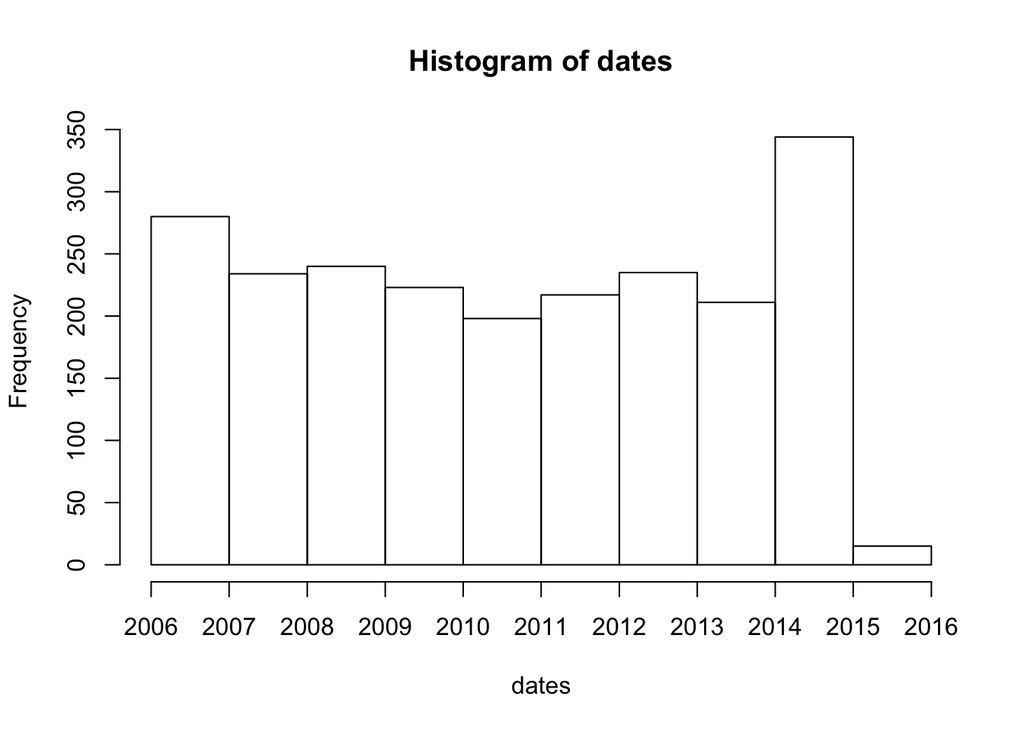

[figure not shown]

```r
r <- regexec("<dd>[F|f]ound on (.*?)</dd>", homicides)
m <- regmatches(homicides, r)
dates <- sapply(m, function(x) x[2])
dates <- as.Date(dates, "%B %d, %Y")
hist(dates, "year", freq = TRUE)
```

### Recursos adicionales

- [Tidy Data](http://vita.had.co.nz/papers/tidy-data.pdf), Hadley Wickham.
- [The Slit-Apply-Combine Strategy for Data Analysis](http://www.jstatsoft.org/v40/i01/paper), Hadley Wickham 2011.
- [Data Wrangling Cheat Sheet](https://www.rstudio.com/wp-content/uploads/2015/02/data-wrangling-cheatsheet.pdf), RStudio.